```python
from adsy.display import extended_styles
%matplotlib inline
```

```python
extended_styles()
```

Toggle Input

# Data Issues

This is the result of an initial data exploration. Here I do not suggest any methods of fixing, I just point out the problems and then we can collectively decide what needs to be fixed and how to acheive that. Click the toggle input button (above) to hide all of the code.

```python
import pandas as pd
import numpy as np
from matplotlib import pyplot as plt
#Uncomment to read in data again
rawdata  = pd.read_csv("./allziptot.csv")
rawdata.index.name="row"
```

### Data Issue 1

This is nothing that needs to be addressed for the Neural Network project but it might affect some of the databases. Zipcode 37892 has two entires for 1995. They are in rows (0 indexed) 54663 and 54664:

```python
print rawdata.ix[54663:54664]
```

```
         zip  zipstr  year  emp
row
54663  37892   37892  1995    0
54664  37892   37892  1995    0
```

```python
rawdata = rawdata.drop(54663) # Drop the duplicate
data = rawdata.set_index(["year", "zip"]) # Reindex by year and zip
yearpan = data.to_panel() # Change to a panel dataframe
datainv = rawdata.set_index(["zip", "year"]) # Another panel by zip and year
zippan = datainv.to_panel()
#pctch = yearpan.pct_change()
```

### Data issue 2a

Approximately 17% of the values are $0$:

```python
print np.sum(rawdata.emp==0)/float(len(rawdata)) * 100, r"% of the entries are 0"
```

```
17.1455043571 % of the entries are 0
```

### Data issue 2b

While some of the $0$ values might be because the employment is actually $0$ (or close to $0$) that is certainly not the case for all zipcodes. For example, take a look at the time series of zipcode 20010 (where I used to live in DC).

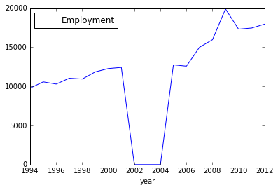

```python
plot_employment_at_zip(20010);
```

Note that these are not *labeled* missing values (though I suspect they chould be NaNs and not 0's).

To be more specific, let's see how many zipcodes appear to have missing values (as in the case of 20010). To do this, we count the number of zip-codes whose **average employment is greater than $500$ but contain at least one $0$:**

```python
grouped=rawdata.groupby("zip")
outliers = 0
lowemp = 0
for name, group in grouped:
     if np.mean(group.emp) >500 and min(group.emp)==0:
            outliers+=1
     if np.mean(group.emp) < 500 and min(group.emp)==0:
        lowemp +=1
print "Out of ", len(grouped), " zipcodes, at least", outliers, " have missing values" ,
```

[output not shown]

Let's see what some of these look like:

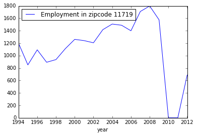

```python
plot_employment_at_zip(11719);
```

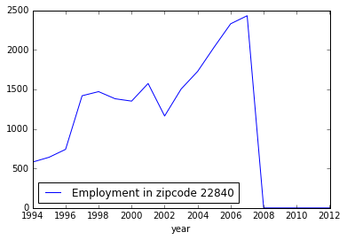

```python
plot_employment_at_zip(22840);
```

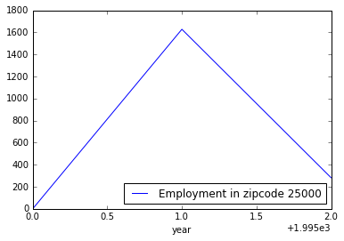

```python
plot_employment_at_zip(25000);
```

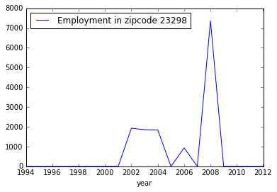

```python
plot_employment_at_zip(23298);
```

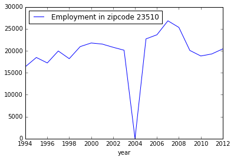

```python
plot_employment_at_zip(23510);
```

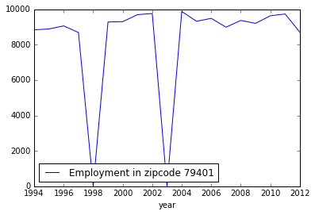

```python
plot_employment_at_zip(79401);
```

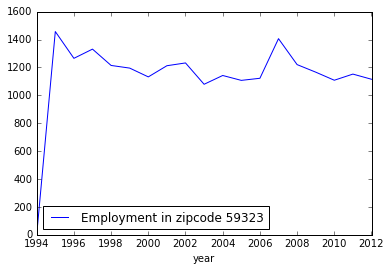

```python
plot_employment_at_zip(59323);
```

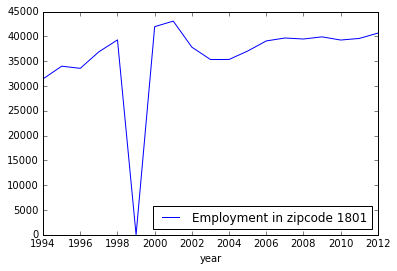

```python
plot_employment_at_zip(1801);
```

Basically. the zeros can show up (sometimes twice) in any year.

### Data Issue 3

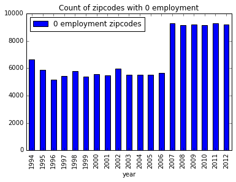

```python
yeargroup = rawdata.groupby("year")
counted=yeargroup.emp.value_counts(0).to_frame()
#countedzeros = counted[counted.emp==0]
ax = counted.xs(0,level="emp").plot(kind="bar", legend=True, title="Count of zipcodes with 0 employment");
lines, labels = ax.get_legend_handles_labels()
ax.legend(lines, ["0 employment zipcodes"], loc=2)
```

### Data Issue 4

There is a zipcode $99999$ that has a ton of employment. For example, in 2012 the zipcode had over 2 million employees. Unfortunately, zipcode $99999$ does not exist in the US.

```python
rawdata[rawdata.zip==99999][["zip", "year", "emp"]]
```

| row | zip | year | emp |
| --- | --- | --- | --- |
| 39258 | 99999 | 1994 | 281901 |
| 79190 | 99999 | 1995 | 391860 |
| 119289 | 99999 | 1996 | 395286 |
| 159537 | 99999 | 1997 | 0 |
| 199004 | 99999 | 1998 | 657567 |
| 238765 | 99999 | 1999 | 343205 |
| 278618 | 99999 | 2000 | 660510 |
| 318435 | 99999 | 2001 | 995266 |
| 357886 | 99999 | 2002 | 1308492 |
| 397309 | 99999 | 2003 | 1510225 |
| 436892 | 99999 | 2004 | 0 |
| 476517 | 99999 | 2005 | 0 |
| 516174 | 99999 | 2006 | 0 |
| 555826 | 99999 | 2007 | 2526461 |
| 595066 | 99999 | 2008 | 2687116 |
| 634240 | 99999 | 2009 | 2555259 |
| 673344 | 99999 | 2010 | 2552736 |
| 712376 | 99999 | 2011 | 2674274 |
| 751194 | 99999 | 2012 | 2733406 |

# Code - Ignore Anything Below This

```python
def plot_employment_at_zip(zipcode, data=rawdata):
    zipdata = data[data["zip"]==zipcode]
    ax = zipdata.plot("year", "emp", legend=True, label="Employment in zipcode " +str(zipcode))
    #plt.legend("Employment")
    return ax

def check_dup_ix(data=rawdata):
    for year in data.year.unique():
        yeardata = data[data.year==year]
        print "The number of zipcodes are ", len(yeardata.zip), " and the number of unique zipcodes are ", len(yeardata.zip.unique())
    return "Done"

def dupzip95(data):
    d95 = data[data.year==1995]
    counted = []
    for zcode in d95.zip:
        if zcode not in counted:
            counted.append(zcode)
        else:
            print zcode

def emp_hist_by_year(pctchd):
    fig, axes = plt.subplots(4,5)
    for ix, year in enumerate(np.arange(1994, 2013)):
        data = pctchd.major_xs(year).emp.values
        print ix/4, ix%5
        ax = axes[(ix)/5][ix%5]
        ax.hist(data, bins=np.arange(-.5,.5,.01))
        ax.set_title(year)
    fig.tight_layout()
    return fig, ax
```

```python
# outliers = 0
# lowemp = 0
# for name, group in grouped:
#      if np.mean(group.emp) >500 and min(group.emp)==0:
#             outliers+=1
#             print group.zip.values[0]
#      if np.mean(group.emp) < 500 and min(group.emp)==0:
#         lowemp +=1
```